# Investigating Medline discoveries

Erwan Moreau

8/9/2021

# Global statistics across years

## Total number of documents by year

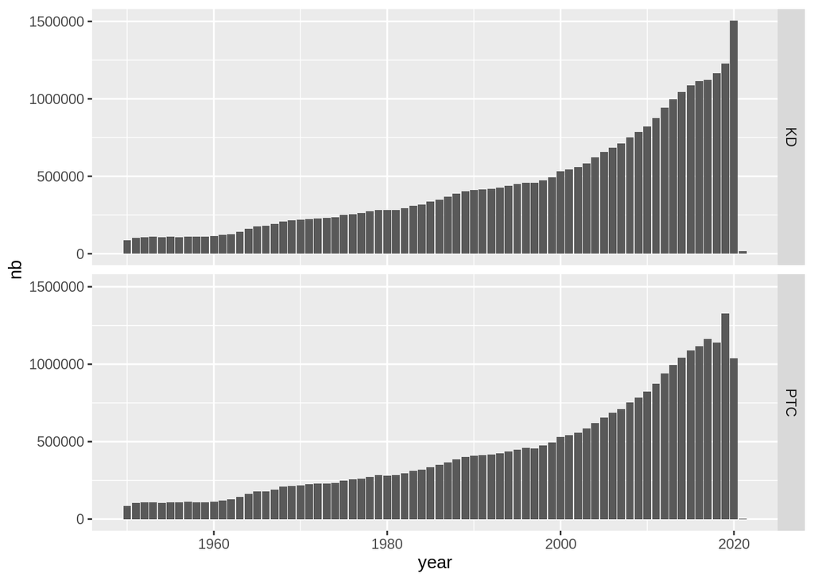

```r
total <- loadTotalFiles(dataPath)
total<-total[total$year>=1950,]
ggplot(total,aes(year,nb))+geom_col()+facet_grid(source~.)
```

## Abstracts vs. Title only (KD)

The following code can be used to generate the simplified table by year from the large table containing all the Medline entries. Running this code requires a large amount of memory.

```
d <-read.table('kd-count-tokens-medline.tsv',sep='\t')
dd<-ddply(d,'year',function(s) { data.frame(abtract=c("no","yes"),count=c(nrow(s[!s$has_abstract,]),nrow(s[s$has_abstract,])),tokens=c(sum(s[,'title']),sum(s[,'abstract']))) })
write.table(dd,'kd-count-tokens-medline-by-year.tsv',row.names=FALSE,quote=FALSE,sep='\t')
```

```r
kdByYear <-read.table(paste(dataPath,'kd-count-tokens-medline-by-year.tsv',sep='/'),sep='\t',header=TRUE)
```

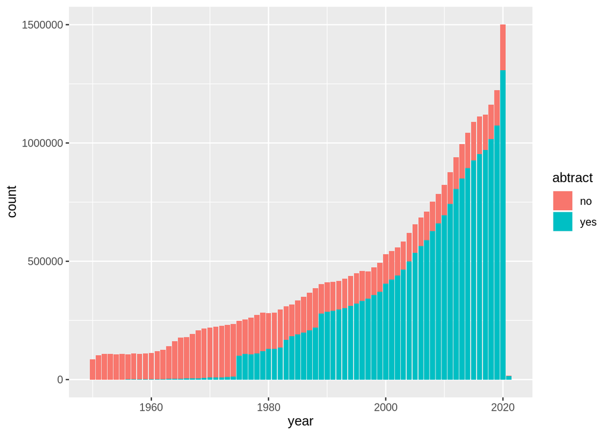

```r
ggplot(kdByYear[kdByYear$year>=1950,],aes(year,count,fill=abtract))+geom_col()
```

The proportion of entries in Medline with abstracts (as opposed to without abstract, i.e. only title) changes drastically between 1974 and 1975:

```r
kable(kdByYear[kdByYear$year>1970 & kdByYear$year<1980,])
```

|  | year | abtract | count | tokens |
| --- | --- | --- | --- | --- |
| 381 | 1971 | no | 214426 | 2539298 |
| 382 | 1971 | yes | 9179 | 1411416 |
| 383 | 1972 | no | 217953 | 2622487 |
| 384 | 1972 | yes | 9857 | 1534234 |
| 385 | 1973 | no | 220712 | 2725214 |
| 386 | 1973 | yes | 10415 | 1648633 |
| 387 | 1974 | no | 222981 | 2834987 |
| 388 | 1974 | yes | 12126 | 1949701 |
| 389 | 1975 | no | 148911 | 3013422 |
| 390 | 1975 | yes | 100276 | 14880344 |
| 391 | 1976 | no | 145838 | 3085597 |
| 392 | 1976 | yes | 109114 | 16194838 |
| 393 | 1977 | no | 155408 | 3189691 |
| 394 | 1977 | yes | 106757 | 14968741 |
| 395 | 1978 | no | 161386 | 3325270 |
| 396 | 1978 | yes | 111134 | 15584097 |
| 397 | 1979 | no | 162186 | 3455980 |
| 398 | 1979 | yes | 119885 | 17138431 |

## Number of tokens by year (KD)

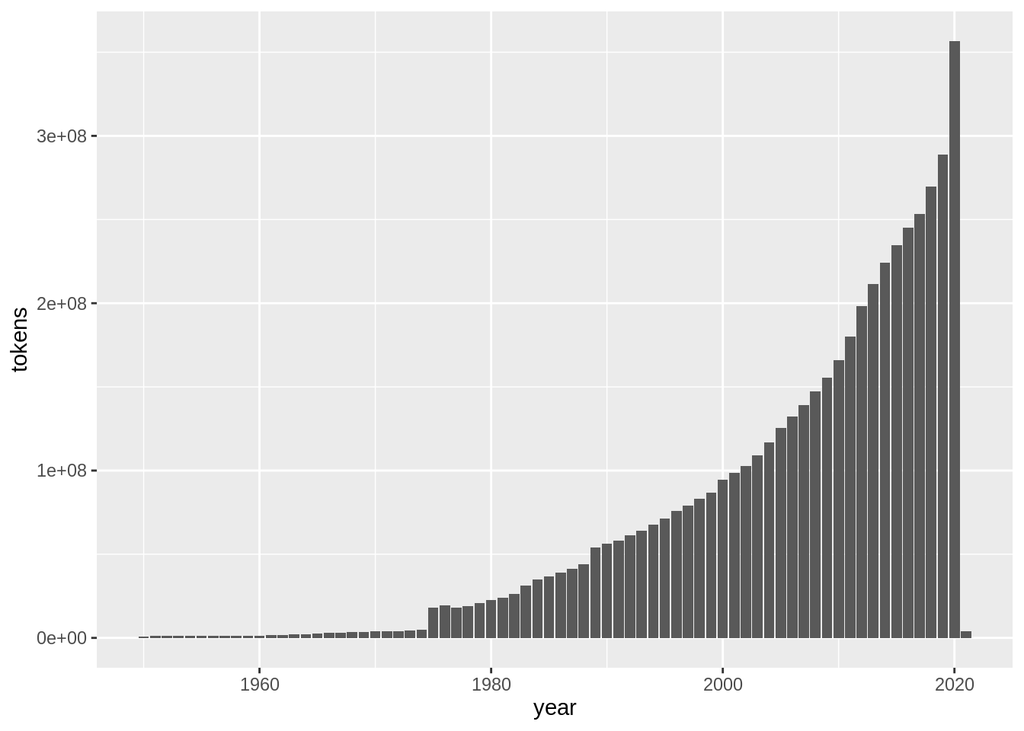

```r
ggplot(kdByYear[kdByYear$year>=1950,],aes(year,tokens))+geom_col()
```

## Number of sentences by year

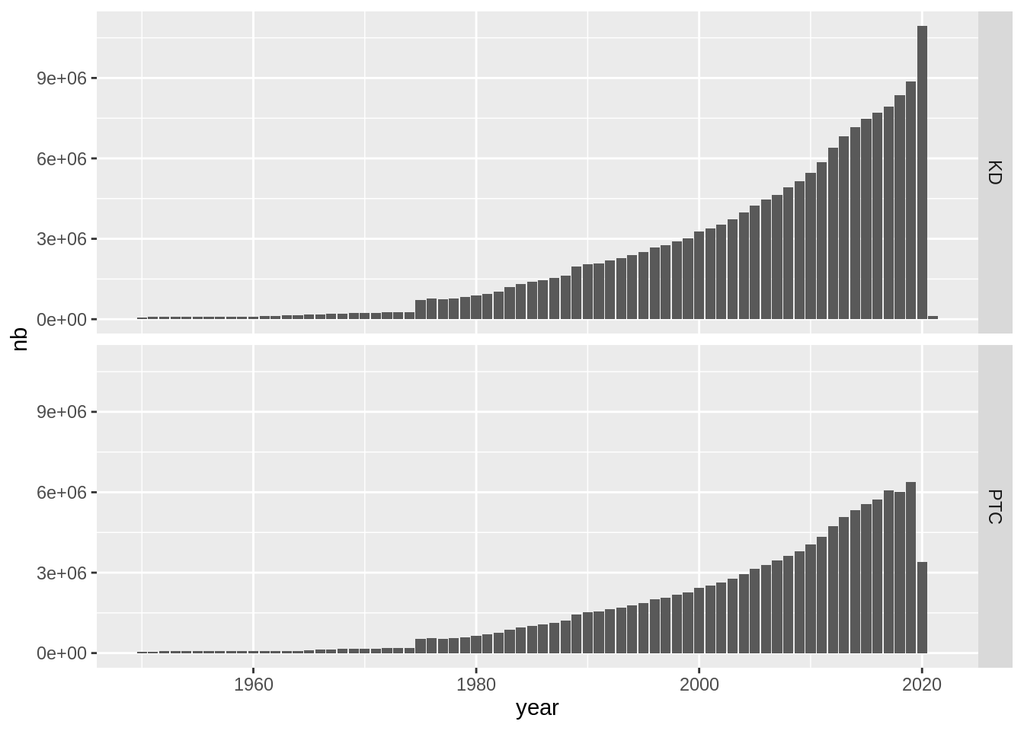

```r
sent<-loadTotalFiles(dataPath,by='by-sent')
ggplot(sent[sent$year>=1950,],aes(year,nb))+geom_col()+facet_grid(source~.)
```

```r
kable(sent[sent$year>1970 & sent$year<1980,])
```

|  | year | unique_concepts | nb | concepts_mentions | source |
| --- | --- | --- | --- | --- | --- |
| 191 | 1971 | 33182 | 239129 | 544725 | KD |
| 192 | 1972 | 33980 | 247804 | 575974 | KD |
| 193 | 1973 | 35297 | 254315 | 599270 | KD |
| 194 | 1974 | 36470 | 266556 | 645714 | KD |
| 195 | 1975 | 52439 | 723006 | 2085624 | KD |
| 196 | 1976 | 54559 | 772783 | 2243259 | KD |
| 197 | 1977 | 54692 | 741974 | 2130196 | KD |
| 198 | 1978 | 56054 | 768513 | 2209378 | KD |
| 199 | 1979 | 58377 | 825983 | 2398462 | KD |
| 433 | 1971 | 15219 | 172063 | 274863 | PTC |
| 434 | 1972 | 15701 | 178424 | 287681 | PTC |
| 435 | 1973 | 16321 | 184067 | 298455 | PTC |
| 436 | 1974 | 16843 | 192847 | 317179 | PTC |
| 437 | 1975 | 24348 | 517886 | 974531 | PTC |
| 438 | 1976 | 25398 | 555242 | 1055563 | PTC |
| 439 | 1977 | 24936 | 532053 | 1002362 | PTC |
| 440 | 1978 | 25410 | 556041 | 1052334 | PTC |
| 441 | 1979 | 26599 | 592928 | 1125256 | PTC |

# Discovery year

## Number of concepts/pairs by group and proportion of NA cases

```r
d <- loadAllDiscoveriesFiles(dataPath)
```

```
## [1] "full.min100/indiv/KD.05.stats"
## [1] "full.min100/indiv/KD.10.stats"
## [1] "full.min100/indiv/PTC.05.stats"
## [1] "full.min100/indiv/PTC.10.stats"
## [1] "full.min100/joint/KD.05.stats"
## [1] "full.min100/joint/KD.10.stats"
## [1] "full.min100/joint/PTC.05.stats"
## [1] "full.min100/joint/PTC.10.stats"
```

```r
kable(statsByGroup(d))
```

| source | indivOrJoint | window_size | rows | nas | propNA |
| --- | --- | --- | --- | --- | --- |
| KD | indiv | 5 | 68304 | 6 | 0.0000878 |
| KD | indiv | 10 | 68304 | 6 | 0.0000878 |
| KD | joint | 5 | 2840392 | 758 | 0.0002669 |
| KD | joint | 10 | 2840392 | 758 | 0.0002669 |
| PTC | indiv | 5 | 33803 | 2 | 0.0000592 |
| PTC | indiv | 10 | 33803 | 2 | 0.0000592 |
| PTC | joint | 5 | 317656 | 11 | 0.0000346 |
| PTC | joint | 10 | 317656 | 11 | 0.0000346 |

## Distribution of ratio values

Note: the Y count is not correct in the following graphs since a random subset of the data is used.

```r
d0 <- d[sample(nrow(d),200000),]
```

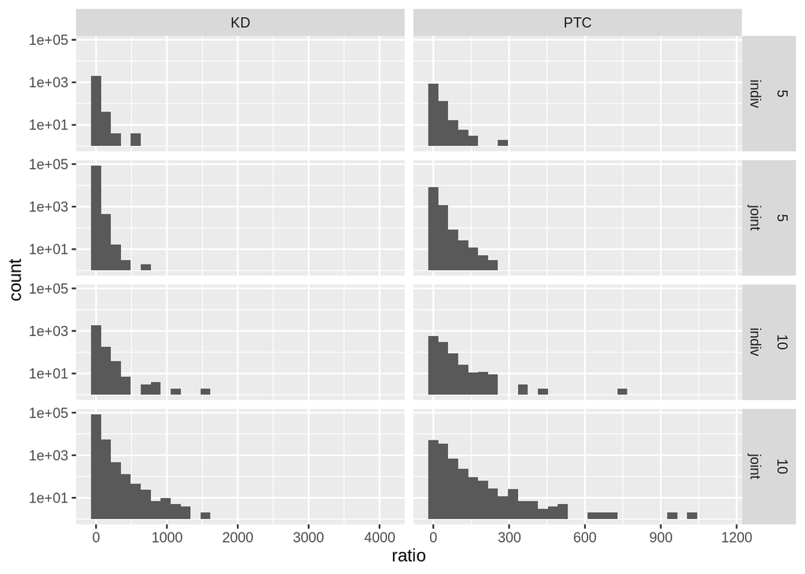

```r
plotDistribRatio(d0)
```

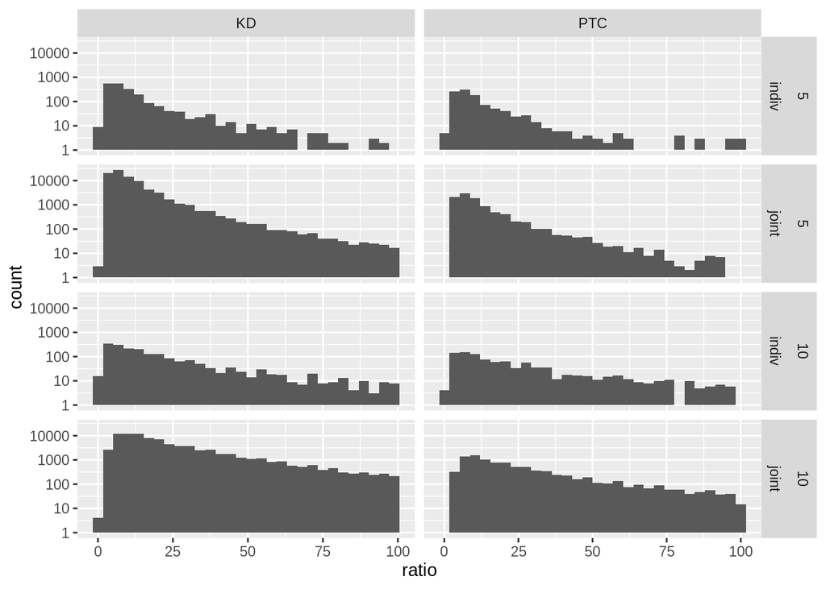

```r
plotDistribRatio(d0,100)
```

```r
q<-ddply(d,c('source','indivOrJoint','window_size'),function(s) {
  quantile(s$ratio,probs=seq(0,1,.1),na.rm=TRUE)
})
kable(q)
```

| source | indivOrJoint | window_size | 0% | 10% | 20% | 30% | 40% | 50% | 60% | 70% | 80% | 90% | 100% |
| --- | --- | --- | --- | --- | --- | --- | --- | --- | --- | --- | --- | --- | --- |
| KD | indiv | 5 | 1.0000000 | 3.400000 | 4.5 | 5.428571 | 6.5 | 7.857143 | 9.0 | 11.66667 | 16.00000 | 26 | 6383.727 |
| KD | indiv | 10 | 0.3750000 | 3.806452 | 6.0 | 8.000000 | 11.0 | 14.000000 | 19.0 | 27.00000 | 41.50000 | 79 | 19197.000 |
| KD | joint | 5 | 0.0000000 | 4.000000 | 5.0 | 6.000000 | 7.0 | 8.000000 | 9.0 | 11.00000 | 14.00000 | 20 | 8006.000 |
| KD | joint | 10 | 0.5000000 | 7.000000 | 9.0 | 11.500000 | 14.0 | 17.000000 | 22.0 | 28.00000 | 37.50000 | 58 | 13597.000 |
| PTC | indiv | 5 | 0.0000000 | 3.583333 | 4.8 | 6.000000 | 7.0 | 8.000000 | 10.0 | 13.00000 | 17.00000 | 28 | 1871.000 |
| PTC | indiv | 10 | 0.8969555 | 4.208093 | 6.5 | 9.000000 | 12.0 | 16.000000 | 22.0 | 31.00000 | 47.00000 | 84 | 5230.000 |
| PTC | joint | 5 | 0.0000000 | 4.000000 | 5.0 | 6.000000 | 7.0 | 8.000000 | 10.0 | 12.00000 | 15.11111 | 23 | 1167.000 |
| PTC | joint | 10 | 0.0000000 | 7.000000 | 9.0 | 11.500000 | 14.0 | 18.000000 | 22.5 | 29.16667 | 41.00000 | 65 | 5927.000 |

# Relation between frequency and ratio

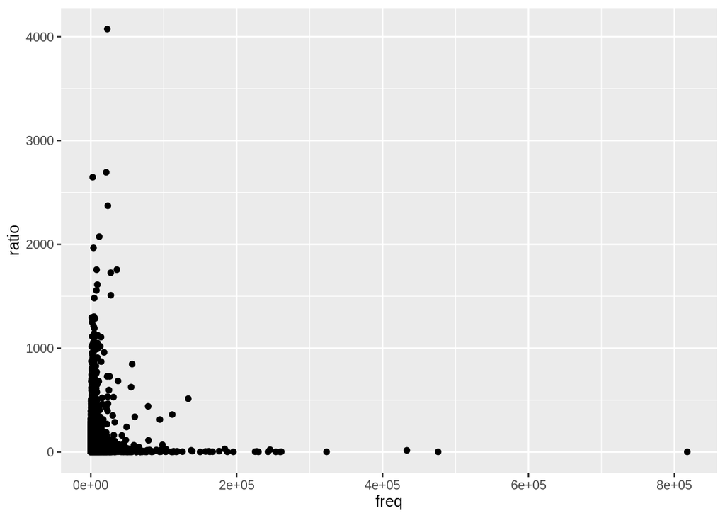

```r
ggplot(d0,aes(freq,ratio))+geom_point()
```

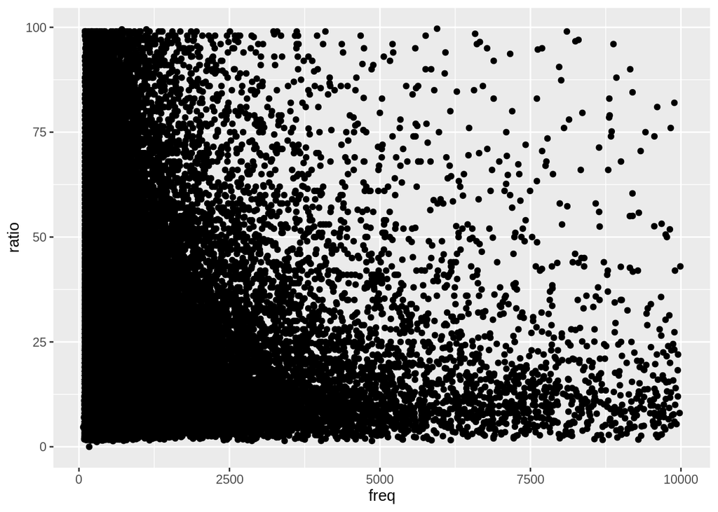

```r
ggplot(d0[d0$freq<10000 & d0$ratio<100,],aes(freq,ratio))+geom_point()
```

Correlation:

```r
cor(d$ratio, d$freq,use="complete.obs")
```

```
## [1] 0.03457168
```

# Discovery years

## Distribution of discovery years

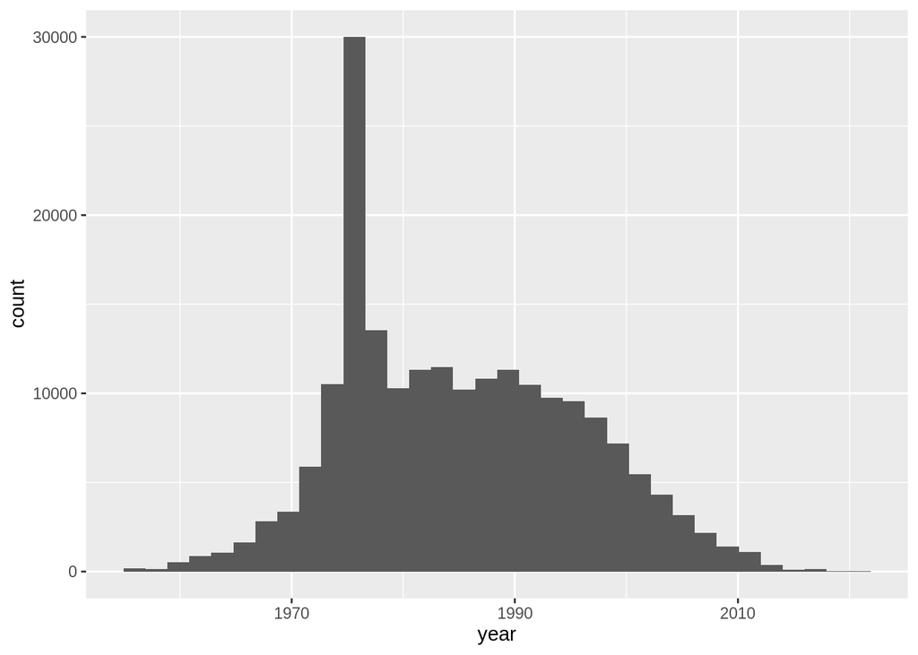

```r
plotDistribDiscoveryYears(d0,'year',byGroup=FALSE)
```

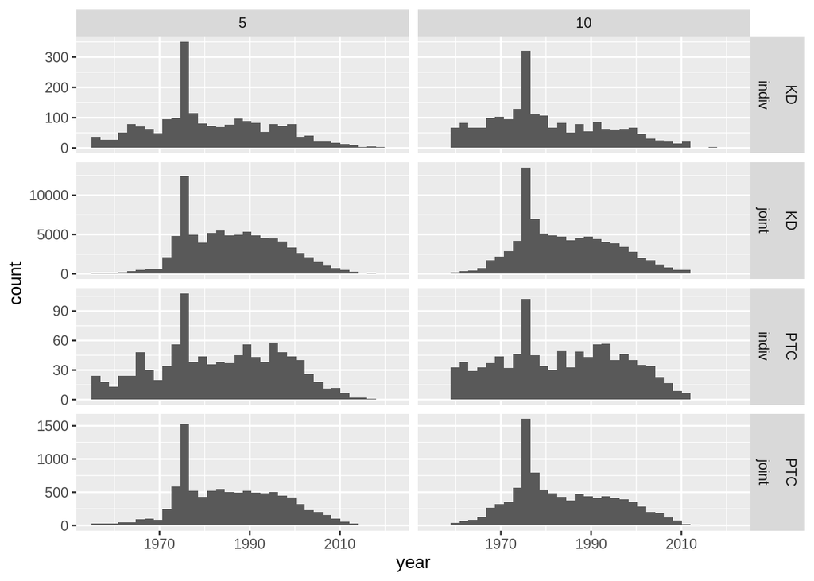

```r
plotDistribDiscoveryYears(d0,'year')
```

The peak in the 70s is very likely caused by a large amount of new concepts added around this time, as can be seen on the distribution of the first year:

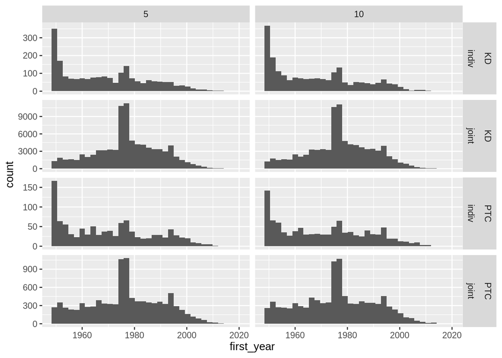

```r
plotDistribDiscoveryYears(d0,'first_year')
```

Hypothesis: the progressive decrease in amount of discoveries after the 90s might be due to the fact that the probability of a peak decreases with time.

## Relation between first year and discovery year

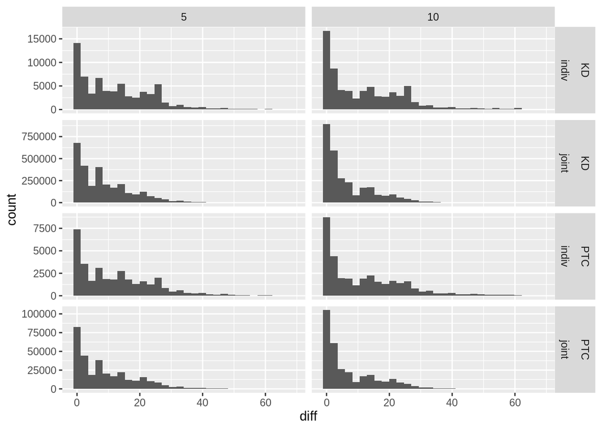

```r
plotDiffFirstYear(d)
```

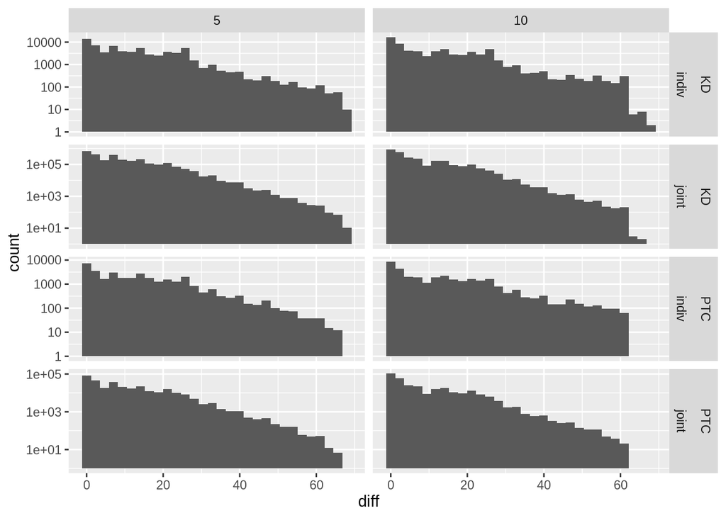

```r
plotDiffFirstYear(d,log=TRUE)
```

Proportion of cases where the difference between discovery and first year is less than the window size:

```r
kable(proportionDiffLowerWindowByGroup(d))
```

| source | indivOrJoint | window_size | prop |
| --- | --- | --- | --- |
| KD | indiv | 5 | 0.3355440 |
| KD | indiv | 10 | 0.5059879 |
| KD | joint | 5 | 0.4231603 |
| KD | joint | 10 | 0.7165849 |
| PTC | indiv | 5 | 0.3503535 |
| PTC | indiv | 10 | 0.5187114 |
| PTC | joint | 5 | 0.4337459 |
| PTC | joint | 10 | 0.6888647 |

Note: for joint discoveries the proportion of “discovery year” in the first year within the window size is very high:

- around 43% with window size 5
- around 70% with window size 10

# Study considering first year of both individual concepts in joint relation

Idea: study whether the two individual concepts appeared (first year) before or after the year of discovery minus window size: if yes, then the ‘past’ frequency can be considered meaningful, but if not it could be an artifact of the method.

```r
j<-addIndivInfoToJoint(d)
```

```
##   source window_size
## 1     KD           5
##   source window_size
## 1     KD          10
##   source window_size
## 1    PTC           5
##   source window_size
## 1    PTC          10
```

Proportion of cases where the difference between discovery and latest first indiv year (i.e. first year where both individual concepts exist) is less than the window size:

```r
proportionDiffLowerWindowByGroupJoint(j)
```

```
##   source window_size       prop
## 1     KD           5 0.05055711
## 2     KD          10 0.12920153
## 3    PTC           5 0.07992294
## 4    PTC          10 0.16977170
```

This is the distribution of ‘diff year’ i.e. time between the first joint occurrence and discovery year, with the label/colour being:

- ‘no’: the discovery year is at least N years after first occurrence (with N the window size)
- ‘joint_first’ the discovery year is within the first N years after the first joint occurrence
- ‘indiv_first’ the discovery year is within the first N years after the first occurrence of the last individual occurrence
  - I.e. if A appears in 1954 and B appears in 1967 then B is the last; if the discovery year for the relation A-B is within 1967+N then the case belongs to the ‘indiv_first’ category.
  - Note: the ‘indiv first’ cases are a subset of the ‘joint first’ cases since the last individual occurrence always happens before (or the same year as) the first joint occurrence.

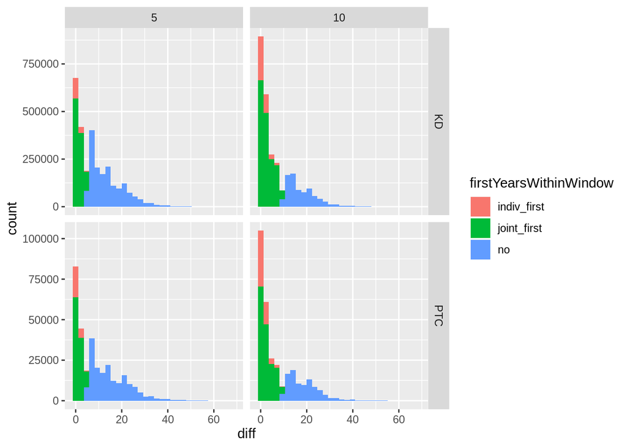

```r
j <-addWindowLabel(j)
j<-addRatioBins(j)
plotDiffFirstYear(j,colourCol='firstYearsWithinWindow')
```

This is the distribution of ‘diff year within window’ which is actually the duration between the first occurrence of the last individual occurrence and the discovery year.

Note that the data follows a more symmetrical distribution. Not sure how to interpret this?

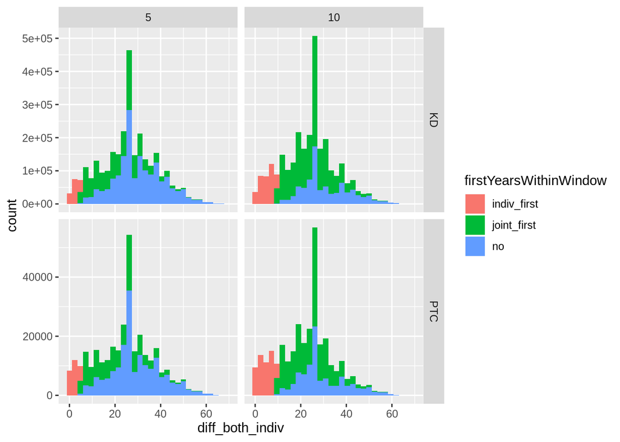

```r
plotDiffFirstYear(j,col='diff_both_indiv',colourCol='firstYearsWithinWindow')
```

# Relation between ratio and year/year diff

As suspected, the highest max ratios are observed within the first N years of the window. This tends to show that there is a bias for these cases, especially the ‘indiv first’ cases.

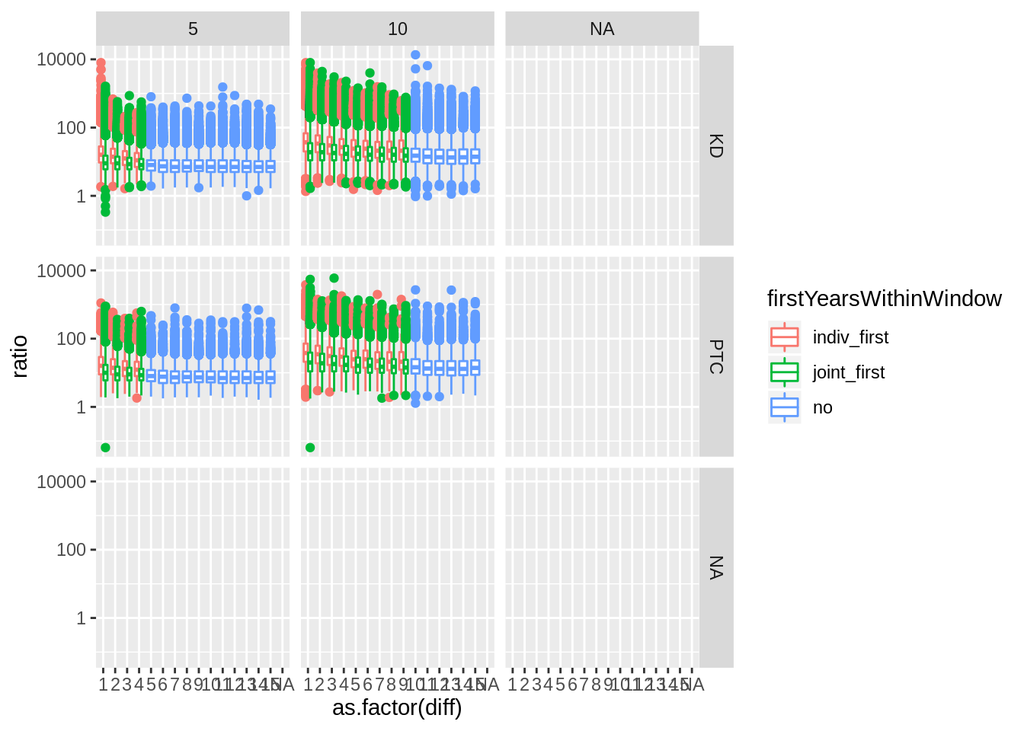

```r
ggplot(j[j$diff<=15,],aes(as.factor(diff),ratio,colour=firstYearsWithinWindow))+geom_boxplot()+scale_y_log10()+facet_grid(source~window_size)
```

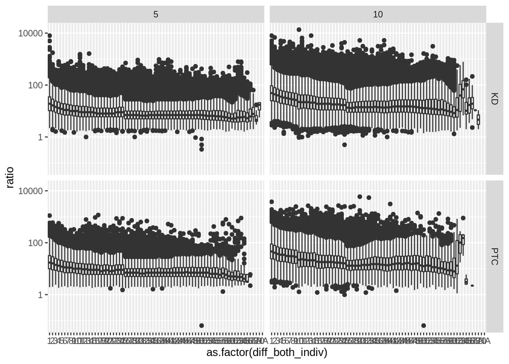

```r
ggplot(j,aes(as.factor(diff_both_indiv),ratio))+geom_boxplot()+scale_y_log10()+facet_grid(source~window_size)
```

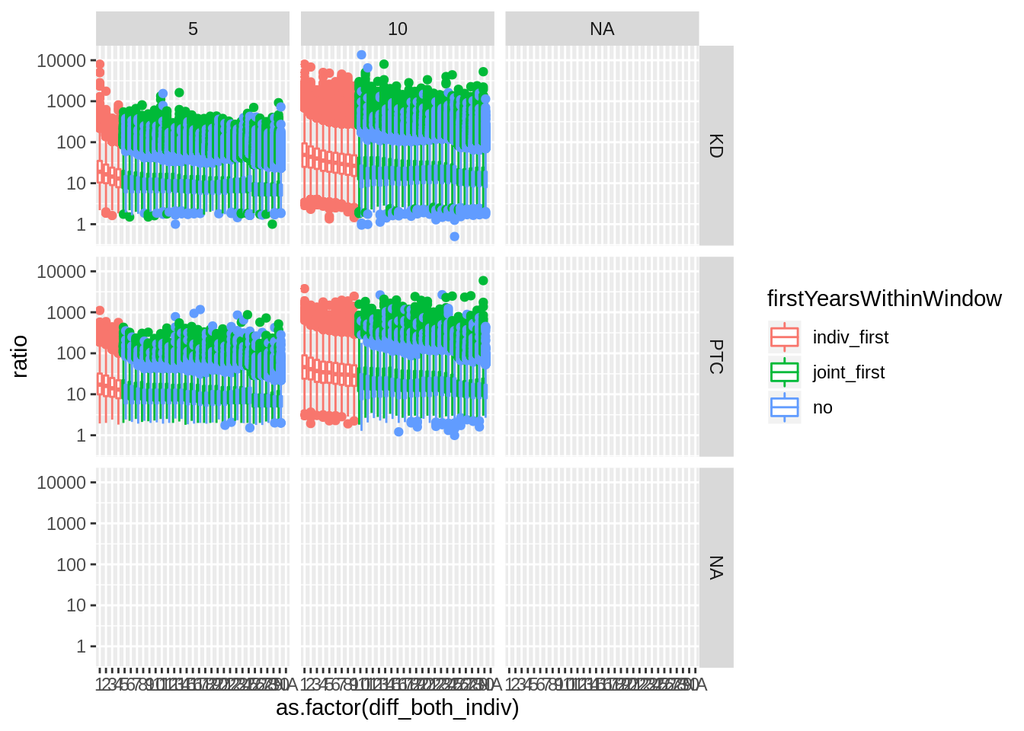

```r
ggplot(j[j$diff_both_indiv<=30,],aes(as.factor(diff_both_indiv),ratio,colour=firstYearsWithinWindow))+geom_boxplot()+scale_y_log10()+facet_grid(source~window_size)
```

## By discovery year

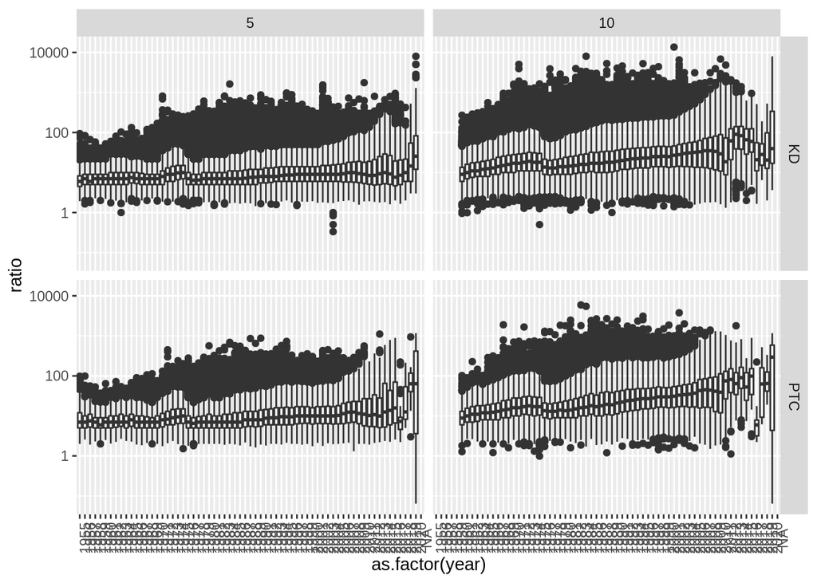

```r
ggplot(j,aes(as.factor(year),ratio))+geom_boxplot()+scale_y_log10()+theme(axis.text.x = element_text(angle = 90))+facet_grid(source~window_size)
```

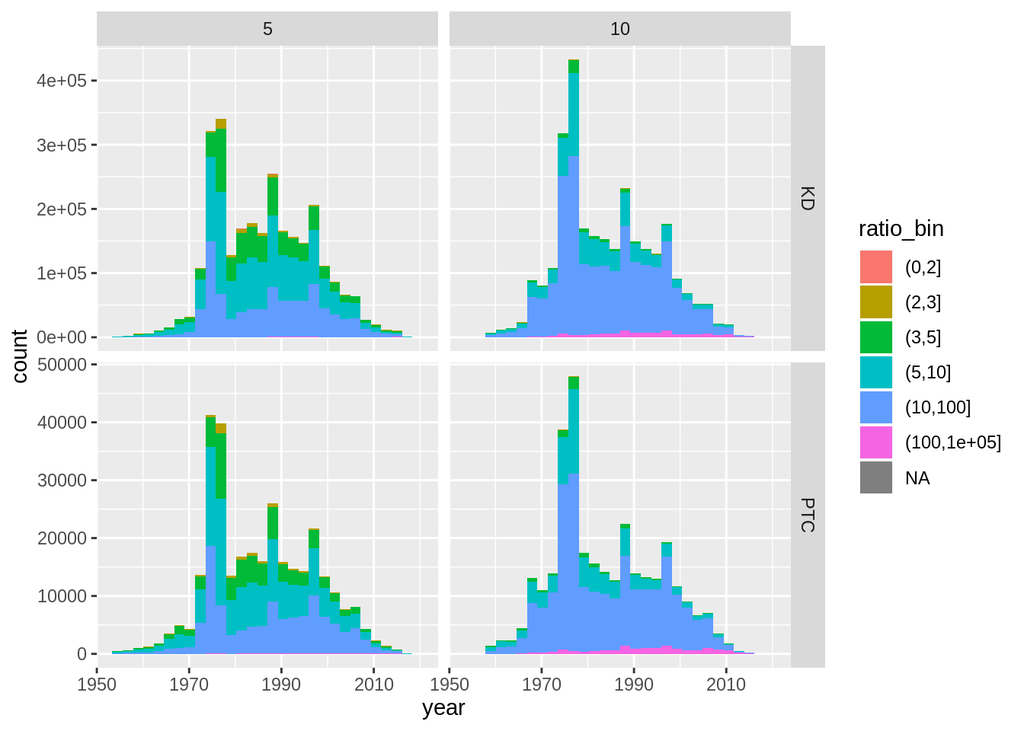

```r
plotDiffFirstYear(j,col='year',colourCol='ratio_bin')
```